# Modelling Results - Likelihood of Infrastructure Project Delivery

Sujith Roy

2024-10-06

# Objective

To assess the feasibility of predicting the likelihood of infrastructure project delivery using data from the Pipeline dataset and easily accessible external sources.

# Overview

The Pipeline dataset contains information on 5,940 infrastructure projects, including project status, funding status, procurement methods, timelines, and geographic details (latitude, longitude).

# Approach

The brute force approach involved creating a weighting system to assign likelihoods based on project sector, region, funding source, and duration spent in specific phases. However, the dataset lacks crucial information, such as how long a project remains in specific statuses (e.g., “On hold,” “In Development”) or reasons behind the statuses. These factors would have made the modeling more straightforward.

While it is possible to manually extract status durations, there were insufficient data points to model the ‘likelihood’ of completion directly. Thus, we focused on an alternative approach—predicting total delay as a proxy for project delivery likelihood.

To support this, several features were engineered from the Pipeline data: • complete: Indicates whether the project is complete. • planned_duration: Planned project duration. • actual_duration: Actual duration of the project. • budget_min and budget_max: Estimated budget range. • funding_status_indicator: Whether the funding source is confirmed. • project_status_indicator: Indicates whether the project is “In planning.” • total_delay: Calculated as the difference between the actual completion date and the estimated completion date for completed projects.

Predicting total delay allows us to estimate the likelihood of project delivery, with higher delays implying lower chances of on-time completion. The predicted delays were then scaled to a likelihood percentage (0-100%) for each project region and sector, normalizing the values to assess the probability of on-time delivery.

# Prediction Outputs from LM1

The output below shows a snapshot of predicted delay and likelihood of project delivery from linear model 1

```
##   PrimaryKey                                     ProjectName
## 1   IP013214    Grey Street Pump Station Upgrade (DC Funded)
## 2   IP011640       Subtransmission Network Relay Replacement
## 3   IP004133 Whakarongo - Installation of Stormwater Systems
## 4   IP006337                              Domestic Processor
##          ProjectRegion predicted_delay likelihood
## 1              Waikato        151.7883   90.58927
## 2             Auckland        305.5918   98.42478
## 3 Manawatū - Whanganui       -618.0986   45.22673
## 4             Auckland       -539.0368   65.54373
```

# Prediction Outputs from LM2

The output below shows a snapshot of predicted delay and likelihood of project delivery from linear model 2

```
##                                ProjectName ProjectRegion
## 1               IAF Active Linear Corridor        Nelson
## 2             Blue Green Network Programme     Northland
## 3           Main Street Trunk Main Upgrade    Canterbury
## 4 WC341L Selwyn Place Pedestrian Crossings        Nelson
##   EstimatedQuarterProjectRangeCompletion predicted_delay likelihood
## 1                             2027-01-01       118.92297   82.23079
## 2                             2031-04-01      -757.24888   35.49099
## 3                             2029-04-01        28.61516   71.06726
## 4                             2028-01-01        86.81299   78.65408
##    ProjectStatus
## 1 Early planning
## 2    In planning
## 3    In planning
## 4    In planning
```

# LM1 1: Plot 1 - Predicted Delay Faceted by Region and Sector

This graph below shows the distribution of expected delays across regions for the planned projects. The fit for LM1 was not strong enough to use in production or for decision-making.

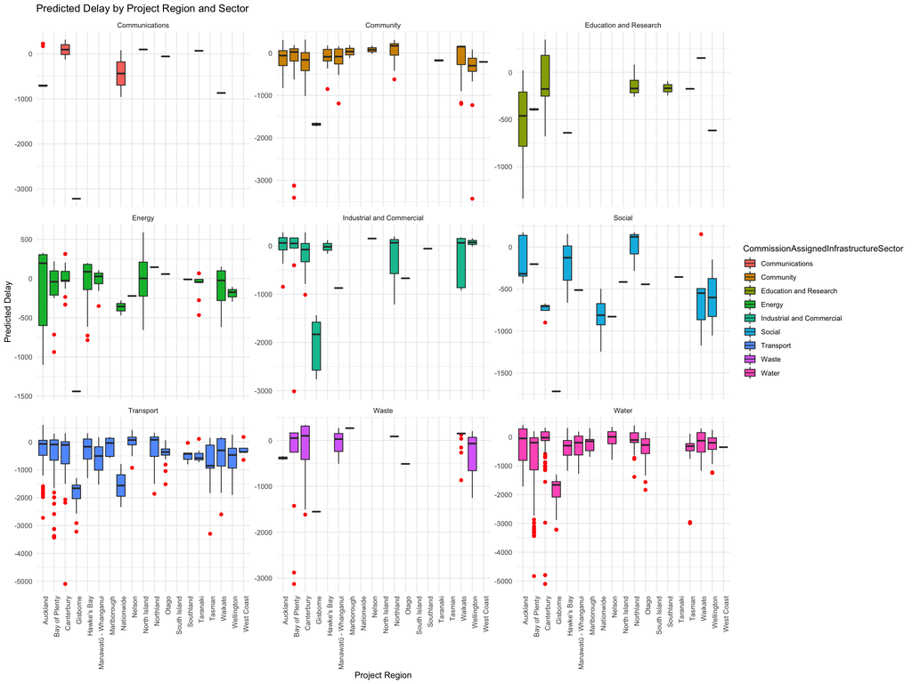

# LM1 1: Plot 2 - Pedicted Likelihood Faceted by Region and Sector

The graph below shows the distribution of likelihood project delivery across regions for the planned projects. The likelihood distribution is all over the place failing to account for extreme cases.

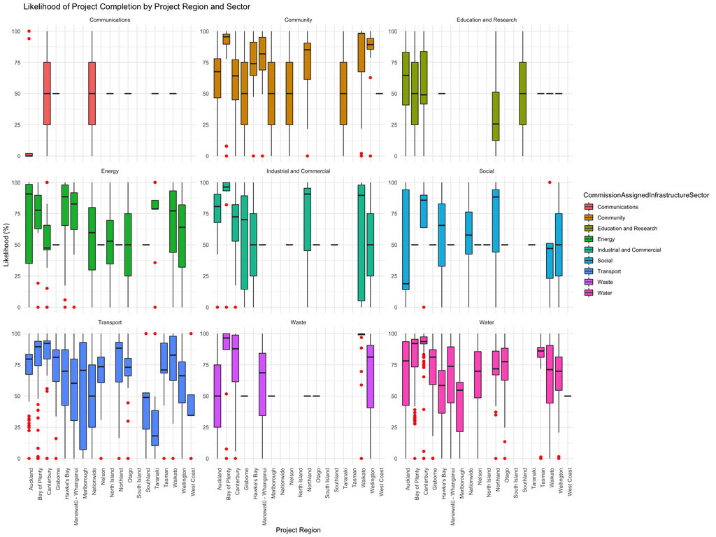

# LM2 1: Plot 1 - Predicted Delay for Transport Sector by Region

This graph below shows the distribution of expected delays across regions for the planned projects in Transport sector. The fit for LM2 was better than LM1 enough to use in production or for decision-making.

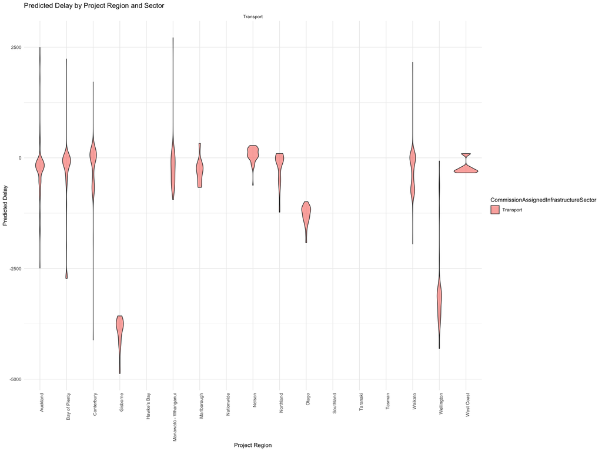

# LM2 1: Plot 2 - Predicted Likelihood of Project Delivery for Transport Sector by Region

The graph below shows the distribution of likelihood project delivery for the planned projects in Transport Sector.

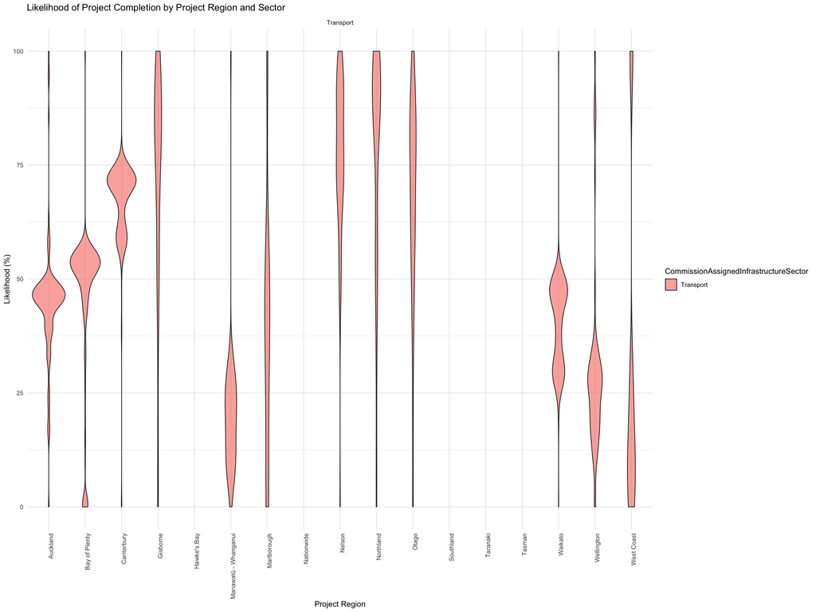

# Final Model LM2 Diagnostics

# Model Summary

Final input variables are average delay in the sector, minimum budget, maximum budget, planned duration, funding status (confirmed or not), project status, Project Region, GDP Delta and CPI Delta Model has an accuracy of ~80%

```r
summary(delay_model_2)
```

```
##
## Call:
## lm(formula = total_delay ~ avg_group_delay + budget_min + budget_max +
##     planned_duration + funding_status_indicator + project_status_indicator +
##     ProjectRegionCode + CPI_Delta_Percent + GDP_Delta_Percent,
##     data = completed_projects)
##
## Residuals:
##      Min       1Q   Median       3Q      Max
## -1804.80   -94.91    23.48   139.00  1268.37
##
## Coefficients:
##                           Estimate Std. Error t value Pr(>|t|)
## (Intercept)              175.63411  111.73779   1.572   0.1192
## avg_group_delay            0.73889    0.09267   7.973 2.89e-12 ***
## budget_min                 6.20271   13.25293   0.468   0.6408
## budget_max                -1.23297    5.58931  -0.221   0.8259
## planned_duration          -0.25993    0.10248  -2.536   0.0128 *
## funding_status_indicator  91.92554   95.56151   0.962   0.3384
## project_status_indicator -32.35917  122.96808  -0.263   0.7930
## ProjectRegionCode          0.73967    9.60861   0.077   0.9388
## CPI_Delta_Percent          0.08534    0.03967   2.152   0.0339 *
## GDP_Delta_Percent          5.35848   10.89189   0.492   0.6238
## ---
## Signif. codes:  0 '***' 0.001 '**' 0.01 '*' 0.05 '.' 0.1 ' ' 1
##
## Residual standard error: 342.8 on 98 degrees of freedom
## Multiple R-squared:  0.8086, Adjusted R-squared:  0.791
## F-statistic: 45.99 on 9 and 98 DF,  p-value: < 2.2e-16
```